# Ford GoBike Trip Data - Slide Deck

## by Eslam Aly

## Investigation Overview

> I am most interested in figuring out the best features that affect the trips durations. So, i generated some plot to describe more my findings.

## Dataset Overview

> This data set includes information about individual rides made in Ford GoBike system covering the greater San Francisco Bay area in 2018. The dataset contains about 183,000 rows and 16 features.

## Visualization 1: Counts of Trip Durations

. The data has a maximum of trip durations of 84,548 sec = 23 hrs, which is a very large duration. So, i excluded large durations (more than 3000 sec = 50 mins).

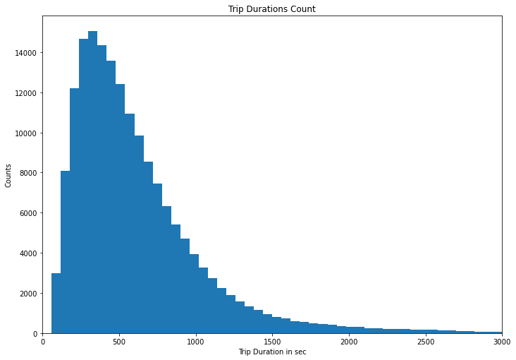

## Visualization 2: Counts of Members Genders

. Males are more frequent to use bikes as a transportation method.

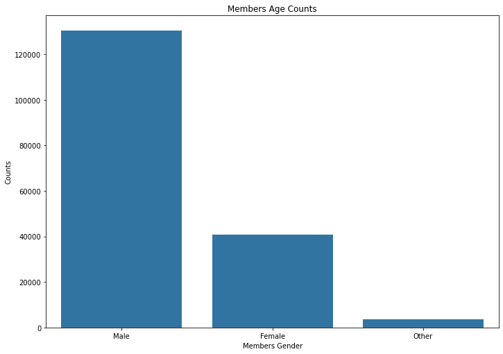

. Surprisingly, the females are making slightly higher durations than men drivers.

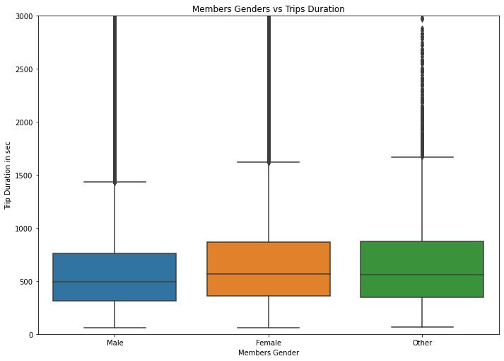

## Visualization 4: Members Age vs. Trip Duration vs. Members Gender

. Men with high age are making higher trip durations more than females with high age.

. In low age comparison, the number are mostly the same.

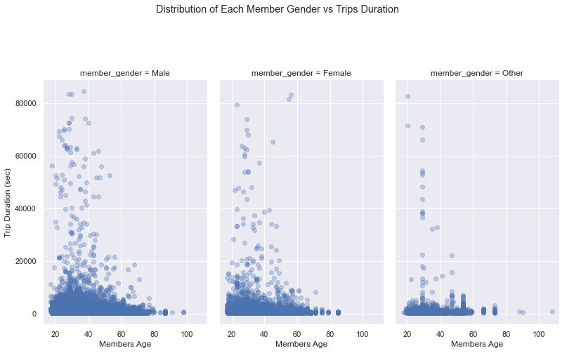

. Female customrs are making higher durations than male customers and all subscribers.

. Female subscribers are making higher durations than male subscribers.

. My increasing tendency is even more increased. Even males counts is much higher than females, the females drivers are making higher trips than men whether they are customers or subscribers.

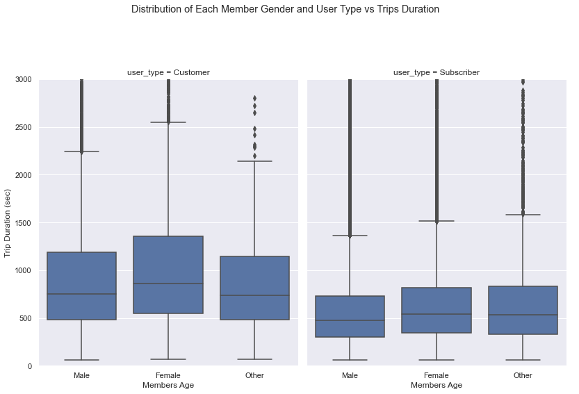